# FinalRExercise_MaZipeng

Amy Ma

September 14, 2020

```r
library(ggpubr)
library(tidyverse)
```

Task 1: Import Data

```r
schools <- read.csv("../data/nys_schools.csv")
acs <- read.csv("../data/nys_acs.csv")
```

Task 2: Explore your data

To keep everything organized, I will explore the schools dataset first and then explore the ACS dataset.

Schools dataset:

```r
#dimension
dim(schools)
```

```
## [1] 35663    12
```

```r
#displaying first few rows of data
head(schools, 2)
```

```
##     school_cd              school_name               district_name
## 1 10100010014 MONTESSORI MAGNET SCHOOL ALBANY CITY SCHOOL DISTRICT
## 2 10100010014 MONTESSORI MAGNET SCHOOL ALBANY CITY SCHOOL DISTRICT
##   county_name           region year total_enroll per_free_lunch
## 1      ALBANY CAPITAL DISTRICT 2008          316           0.33
## 2      ALBANY CAPITAL DISTRICT 2009          312           0.32
##   per_reduced_lunch per_lep mean_ela_score mean_math_score
## 1              0.10    0.01       658.0000        669.6667
## 2              0.08    0.02       672.6667        678.6667
```

```r
#summary statistics
summary(schools)
```

```
##    school_cd                               school_name
##  Min.   :1.010e+10   JOHN F KENNEDY MIDDLE SCHOOL:   40
##  1st Qu.:2.802e+11   JOHN F KENNEDY SCHOOL       :   40
##  Median :3.317e+11   PARK AVENUE SCHOOL          :   40
##  Mean   :3.568e+11   LINCOLN SCHOOL              :   37
##  3rd Qu.:4.725e+11   EAST MIDDLE SCHOOL          :   34
##  Max.   :6.808e+11   WEST MIDDLE SCHOOL          :   34
##                      (Other)                     :35438
##                                district_name     county_name
##                                       : 1706   KINGS   : 4065
##  NEW YORK CITY GEOGRAPHIC DISTRICT #10:  604   BRONX   : 2941
##  NEW YORK CITY GEOGRAPHIC DISTRICT #31:  571   SUFFOLK : 2816
##  NEW YORK CITY GEOGRAPHIC DISTRICT # 9:  520   QUEENS  : 2675
##  NEW YORK CITY GEOGRAPHIC DISTRICT #27:  482   NASSAU  : 2515
##  NEW YORK CITY GEOGRAPHIC DISTRICT # 2:  469   NEW YORK: 2309
##  (Other)                              :31311   (Other) :18342
##               region           year       total_enroll
##  NEW YORK CITY   :12585   Min.   :2008   Min.   : -99.0
##  LONG ISLAND     : 5331   1st Qu.:2010   1st Qu.: 339.0
##  HUDSON VALLEY   : 4422   Median :2013   Median : 469.0
##  WESTERN         : 2868   Mean   :2013   Mean   : 523.6
##  FINGER LAKES    : 2463   3rd Qu.:2015   3rd Qu.: 648.0
##  CAPITAL DISTRICT: 2219   Max.   :2017   Max.   :2347.0
##  (Other)         : 5775
##  per_free_lunch     per_reduced_lunch      per_lep
##  Min.   :-99.0000   Min.   :-99.00000   Min.   :-99.00000
##  1st Qu.:  0.1900   1st Qu.:  0.03000   1st Qu.:  0.00000
##  Median :  0.4200   Median :  0.06000   Median :  0.03000
##  Mean   :  0.4188   Mean   :  0.02852   Mean   :  0.04124
##  3rd Qu.:  0.7200   3rd Qu.:  0.10000   3rd Qu.:  0.11000
##  Max.   :257.0000   Max.   : 53.00000   Max.   :  1.00000
##
##  mean_ela_score  mean_math_score
##  Min.   :-99.0   Min.   :-99.0
##  1st Qu.:296.0   1st Qu.:298.0
##  Median :324.2   Median :330.8
##  Mean   :447.1   Mean   :456.0
##  3rd Qu.:666.3   3rd Qu.:683.5
##  Max.   :720.8   Max.   :738.7
##
```

```r
#data types of each column
str(schools)
```

```
## 'data.frame':    35663 obs. of  12 variables:
##  $ school_cd        : num  1.01e+10 1.01e+10 1.01e+10 1.01e+10 1.01e+10 ...
##  $ school_name      : Factor w/ 5042 levels "2 SCHOOL","30TH AVENUE SCHOOL (THE)",..: 2194 2194 2194 2194 2194 2194 2194 2194 2194 2194 ...
##  $ district_name    : Factor w/ 752 levels "","-99","ABBOTT UNION FREE SCHOOL DISTRICT",..: 8 8 8 8 8 8 8 8 8 8 ...
##  $ county_name      : Factor w/ 63 levels "-99","ALBANY",..: 2 2 2 2 2 2 2 2 2 2 ...
##  $ region           : Factor w/ 11 levels "-99","CAPITAL DISTRICT",..: 2 2 2 2 2 2 2 2 2 2 ...
##  $ year             : int  2008 2009 2010 2011 2012 2013 2014 2015 2016 2017 ...
##  $ total_enroll     : num  316 312 300 326 294 321 335 347 366 359 ...
##  $ per_free_lunch   : num  0.33 0.32 0.26 0.22 0.31 0.25 0.35 0.22 0.29 0.26 ...
##  $ per_reduced_lunch: num  0.1 0.08 0.08 0.07 0.06 0.08 0.04 0 0.02 0.01 ...
##  $ per_lep          : num  0.01 0.02 0.03 0.03 0.03 0.03 0.06 0.06 0.05 0.07 ...
##  $ mean_ela_score   : num  658 673 670 667 670 ...
##  $ mean_math_score  : num  670 679 683 681 687 ...
```

- Dimensions: There are 35663 rows and 12 columns in the schools dataset.
- Through the summary statistics, we can see that the missing values (-99) are present

Looking closer at the missing values:

```r
#total number of missing values across schools dataset
school_mv <- sum(schools == -99)
print(school_mv)
```

```
## [1] 4531
```

```r
#frequency table of missing values
```

There are 4531 missing values in the schools dataset.

ACS dataset:

```r
#dimension
dim(acs)
```

```
## [1] 496   5
```

```r
#displaying first few rows of data
head(acs, 2)
```

```
##   county_name year county_per_poverty median_household_income
## 1      ALBANY 2009          0.1183511                   55350
## 2      ALBANY 2010          0.1194052                   56090
##   county_per_bach
## 1       0.1903682
## 2       0.1971886
```

```r
#summary statistics
summary(acs)
```

```
##       county_name       year      county_per_poverty
##  ALBANY     :  8   Min.   :2009   Min.   :0.04689
##  ALLEGANY   :  8   1st Qu.:2011   1st Qu.:0.10903
##  BRONX      :  8   Median :2012   Median :0.12884
##  BROOME     :  8   Mean   :2012   Mean   :0.13085
##  CATTARAUGUS:  8   3rd Qu.:2014   3rd Qu.:0.14929
##  CAYUGA     :  8   Max.   :2016   Max.   :0.29935
##  (Other)    :448
##  median_household_income county_per_bach
##  Min.   : 33794          Min.   :0.07574
##  1st Qu.: 46347          1st Qu.:0.11018
##  Median : 50135          Median :0.13169
##  Mean   : 54116          Mean   :0.14410
##  3rd Qu.: 56448          3rd Qu.:0.17431
##  Max.   :102044          Max.   :0.31795
##
```

```r
#data types of each column
str(acs)
```

```
## 'data.frame':    496 obs. of  5 variables:
##  $ county_name            : Factor w/ 62 levels "ALBANY","ALLEGANY",..: 1 1 1 1 1 1 1 1 2 2 ...
##  $ year                   : int  2009 2010 2011 2012 2013 2014 2015 2016 2009 2010 ...
##  $ county_per_poverty     : num  0.118 0.119 0.121 0.124 0.123 ...
##  $ median_household_income: int  55350 56090 57715 59359 59394 59940 59887 60904 40917 41305 ...
##  $ county_per_bach        : num  0.19 0.197 0.199 0.198 0.205 ...
```

Confirming absence of missing values in ACS dataset:

```r
sum(acs == -99,na.rm = FALSE)
```

```
## [1] 0
```

There are no missing values in the ACS dataset.

Task 3: Recoding and variable manipulation

```r
schools[schools=="-99"]<-NA
```

```r
#Compute the average of the median household income across all time for each county

#countyincome <- acs %>%
  #group_by(county_name) %>%
  #summarize(avg = mean(median_household_income)) %>%
  #arrange(avg)

#summary(countyincome$avg)

#Find out the standard deviation for income
#incomesd <- sd(countyincome$avg)
#lowerbd <- mean(countyincome$avg) - incomesd
#upperbd <- mean(countyincome$avg) + incomesd
```

I want to see the average poverty rate of each county, regardless of time. This will help seperate the counties into different poverty levels.

```r
#order counties from low to high in terms of mean county per poverty rate
acs_agg <- acs %>%
  group_by(county_name) %>%
  summarise(avgcpp = mean(county_per_poverty),
            avgincome = mean(median_household_income),
            avgcountybach = mean(county_per_bach)) %>%
  arrange(avgcpp)

#head(acs_agg)
```

After computing the average poverty rate, I want to get a better understanding of the distribution and summary statistics of the poverty rates across counties.

```r
#summary statistics for average county per poverty
summary(acs_agg$avgcpp)
```

```
##    Min. 1st Qu.  Median    Mean 3rd Qu.    Max.
## 0.05558 0.11339 0.12883 0.13085 0.14841 0.28671
```

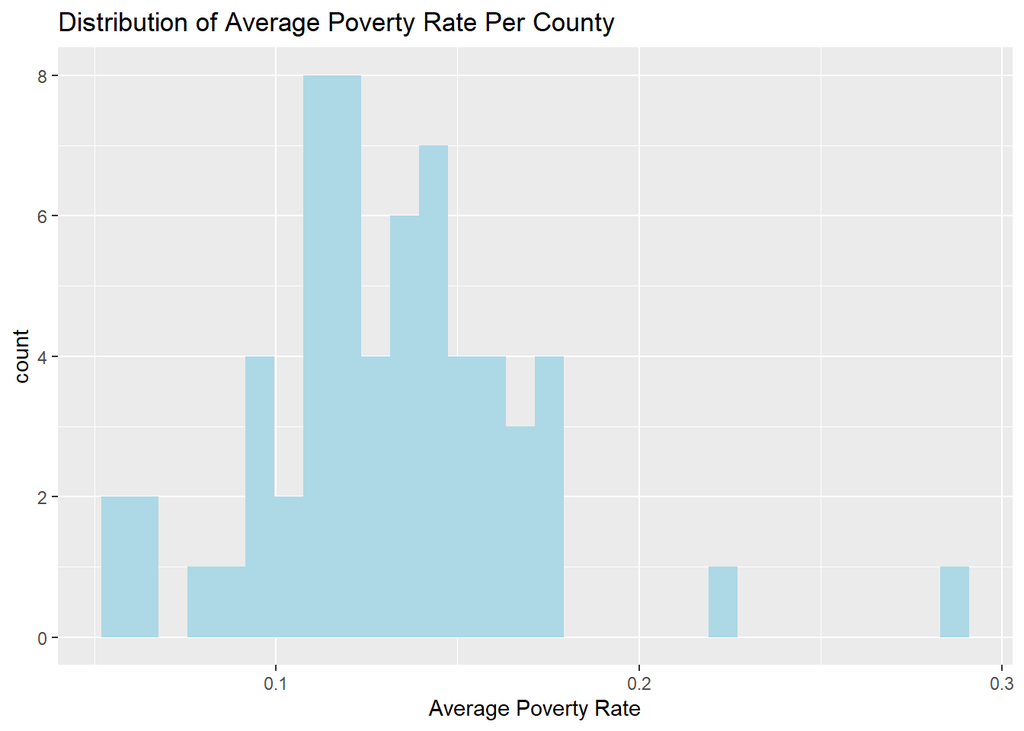

```r
#distribution of average county per poverty
ggplot(acs_agg, aes(x = avgcpp)) +
  geom_histogram(fill = "light blue",
                 bins = 30) +
  labs(title = "Distribution of Average Poverty Rate Per County",
       x = "Average Poverty Rate")
```

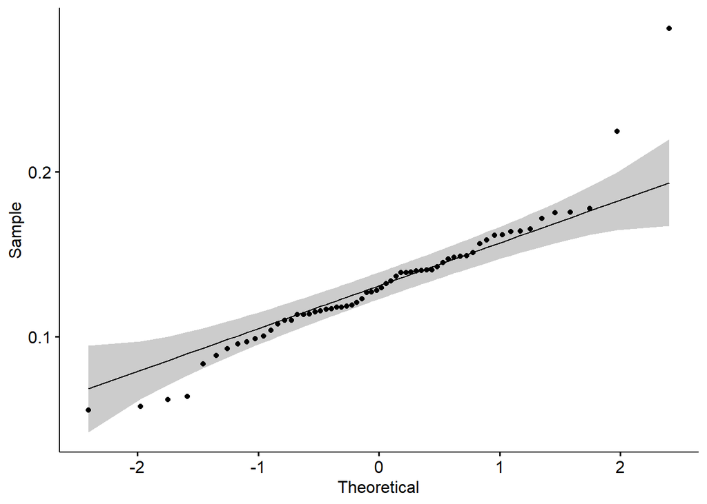

```r
ggqqplot(acs_agg$avgcpp)
```

This is roughly a normal distribution.

I want to assign poverty levels to counties based on the average poverty rates computed earlier. Those within one standard deviation (SD) of the median will be counted as medium poverty level. The majority (roughly 68%) of the counties will fall within one SD. So it would make sense to use SD to determine which counties are medium level. Those above one SD will be high poverty level. Those below one SD will be low poverty level.

```r
#median of poverty rate
povertymed <- median(acs_agg$avgcpp)
povertymed
```

```
## [1] 0.1288258
```

```r
#standard deviation of poverty rate
povertysd <- sd(acs_agg$avgcpp)
povertysd
```

```
## [1] 0.03728472
```

```r
#the upper and lower boundaries of poverty rate within one SD
upper <- povertymed + povertysd
lower <- povertymed - povertysd
```

```r
#create new factor variable povgroup to classify counties into different poverty groups
 acs_agg_pov <- acs_agg %>%
  mutate(povgroup = case_when(
    avgcpp < lower ~ "low",
    avgcpp > lower & avgcpp < upper ~ "medium",
    avgcpp > upper ~ "high"))
```

Create new variable that is the standardized Z-score for math and English Language Arts each year.

```r
schools1 <- schools %>%
  group_by(year) %>%
  mutate(mathscale = scale(mean_math_score),
         elascale = scale(mean_ela_score))
```

Task 4: Merge datasets

Create county-level dataset that merges variables from schools dataset and ACS dataset.

```r
schools_agg <- schools1 %>%
  group_by(county_name) %>%
  drop_na() %>%
  summarize(avgenroll = mean(total_enroll),
            avgfreelunch = mean(per_free_lunch),
            avgreducedlunch = mean(per_reduced_lunch),
            avglep = mean(per_lep),
            avgELA = mean(mean_ela_score),
            avgMathScore = mean(mean_math_score),
            avgmathscale = mean(mathscale),
            avgelascale = mean(elascale))
merged_school_acs <- merge(acs_agg_pov, schools_agg, by = "county_name")
head(merged_school_acs)
```

```
##   county_name    avgcpp avgincome avgcountybach povgroup avgenroll
## 1      ALBANY 0.1230511  58579.88    0.19966348   medium  432.9039
## 2    ALLEGANY 0.1508504  42281.12    0.09407267   medium  382.8973
## 3       BRONX 0.2867147  34421.88    0.11703864     high  575.7780
## 4      BROOME 0.1586677  45716.25    0.14356629   medium  456.8983
## 5 CATTARAUGUS 0.1651814  42811.88    0.09732061   medium  405.2018
## 6      CAYUGA 0.1148767  50686.00    0.11690727   medium  387.1656
##   avgfreelunch avgreducedlunch       avglep   avgELA avgMathScore
## 1    0.3673862      0.05689713 0.0356829680 485.9860     495.2181
## 2    0.4061644      0.11171233 0.0002054795 491.6627     501.3076
## 3    0.8053450      0.05533429 0.1717626028 463.0053     470.4632
## 4    0.3945906      0.07679901 0.0187593052 484.8850     495.3478
## 5    0.4043498      0.10309417 0.0011210762 497.7014     508.1217
## 6    0.3433775      0.07105960 0.0054304636 489.2660     502.5143
##   avgmathscale avgelascale
## 1  0.027673797  0.07325503
## 2 -0.132471610 -0.13014812
## 3 -0.702612780 -0.76773954
## 4 -0.001714199 -0.05018199
## 5 -0.180733704 -0.21339692
## 6  0.033731922 -0.18310022
```

Task 5:Create summary tables

```r
#for each county: total enrollment, percent of students qualifying for free or reduced price lunch, and percent of population in poverty.
sumtable1 <- merged_school_acs %>%
  mutate(freereducedlunch = avgfreelunch+avgreducedlunch) %>%
  select(county_name, avgenroll, freereducedlunch, avgcpp)
head(sumtable1)
```

```
##   county_name avgenroll freereducedlunch    avgcpp
## 1      ALBANY  432.9039        0.4242833 0.1230511
## 2    ALLEGANY  382.8973        0.5178767 0.1508504
## 3       BRONX  575.7780        0.8606793 0.2867147
## 4      BROOME  456.8983        0.4713896 0.1586677
## 5 CATTARAUGUS  405.2018        0.5074439 0.1651814
## 6      CAYUGA  387.1656        0.4144371 0.1148767
```

```r
#create summary table for counties with top 5 and bottom 5 poverty rate
merged_school_acs %>%
  arrange(avgcpp) %>%
  top_n(5)
```

[output not shown]

```
##   county_name     avgcpp avgincome avgcountybach povgroup avgenroll
## 1      NASSAU 0.05557705  97066.88     0.2309520      low  548.5366
## 2      PUTNAM 0.05763953  93794.62     0.2170624      low  645.6533
## 3    SARATOGA 0.06397644  68835.75     0.2139900      low  548.7184
## 4    HAMILTON 0.10386857  50368.50     0.1308357   medium   98.2400
## 5    ROCKLAND 0.12711411  84666.38     0.2249604   medium  504.6928
##   avgfreelunch avgreducedlunch      avglep   avgELA avgMathScore
## 1    0.1748779      0.04258500 0.068509154 498.1457     509.5901
## 2    0.1029333      0.03200000 0.033666667 504.9122     516.3372
## 3    0.1707282      0.04548544 0.006966019 493.3317     503.4612
## 4    0.2166000      0.09920000 0.000000000 519.1927     524.7487
## 5    0.2679256      0.04831703 0.090352250 493.4572     502.8067
##   avgmathscale avgelascale
## 1   0.82119627   0.8881906
## 2   0.61413589   0.6598533
## 3   0.52502699   0.6310879
## 4   0.05263326   0.4526812
## 5   0.27879507   0.3718095
```

Task 6: Relationship between access to free/reduced price lunch and test performance at the school level

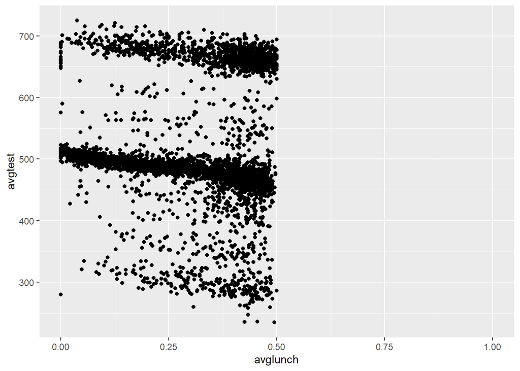

```r
#create a data frame at the school level

schools2 <- schools1 %>%
  group_by(school_name) %>%
  select(school_name, per_free_lunch, per_reduced_lunch, mean_ela_score, mean_math_score) %>%
  mutate(freereducedlunch = (per_free_lunch + per_reduced_lunch)/2) %>%
  summarize(avgfreelunch = mean(per_free_lunch),
            avgreducedlunch = mean(per_reduced_lunch),
            avg_ela = mean(mean_ela_score),
            avg_math = mean(mean_math_score),
            avglunch = mean(freereducedlunch),
            avgtest = (avg_ela + avg_math)/2)

#plot out relationship between access to lunch and test performance
ggplot(schools2, aes(x= avglunch, y = avgtest)) + geom_point() + xlim(0, 1)
```

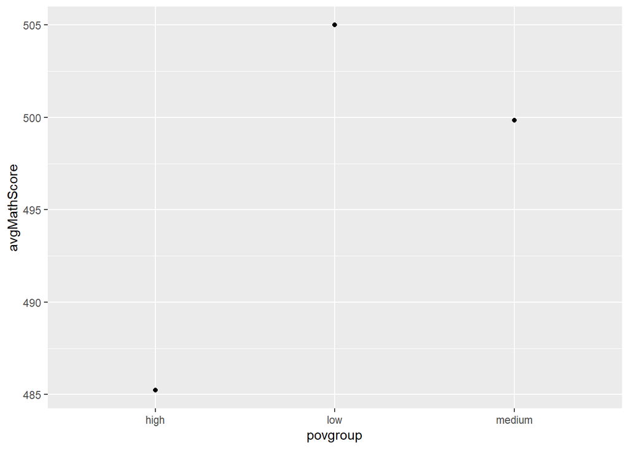

```r
#Average test performance across counties with high, low, medium poverty
merged_school_acs %>%
  group_by(povgroup) %>%
  summarize(avgELA = mean(avgELA),
            avgMathScore = mean(avgMathScore)) %>%
  ggplot(aes(x=povgroup, y = avgMathScore)) + geom_point()
```

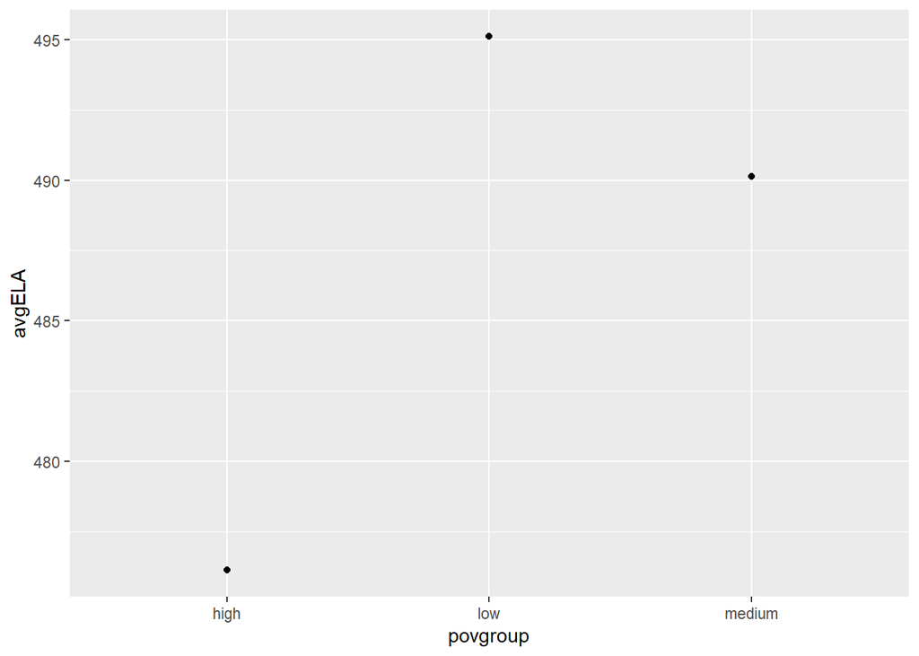

```r
merged_school_acs %>%
  group_by(povgroup) %>%
  summarize(avgELA = mean(avgELA),
            avgMathScore = mean(avgMathScore)) %>%
  ggplot(aes(x=povgroup, y = avgELA)) + geom_point()
```

For both math score and ELA score, there is an inverse relationship between poverty and test performance.

Task 7

```r
#relationship between poverty and test performance in NY public schools
head(merged_school_acs)
```

```
##   county_name    avgcpp avgincome avgcountybach povgroup avgenroll
## 1      ALBANY 0.1230511  58579.88    0.19966348   medium  432.9039
## 2    ALLEGANY 0.1508504  42281.12    0.09407267   medium  382.8973
## 3       BRONX 0.2867147  34421.88    0.11703864     high  575.7780
## 4      BROOME 0.1586677  45716.25    0.14356629   medium  456.8983
## 5 CATTARAUGUS 0.1651814  42811.88    0.09732061   medium  405.2018
## 6      CAYUGA 0.1148767  50686.00    0.11690727   medium  387.1656
##   avgfreelunch avgreducedlunch       avglep   avgELA avgMathScore
## 1    0.3673862      0.05689713 0.0356829680 485.9860     495.2181
## 2    0.4061644      0.11171233 0.0002054795 491.6627     501.3076
## 3    0.8053450      0.05533429 0.1717626028 463.0053     470.4632
## 4    0.3945906      0.07679901 0.0187593052 484.8850     495.3478
## 5    0.4043498      0.10309417 0.0011210762 497.7014     508.1217
## 6    0.3433775      0.07105960 0.0054304636 489.2660     502.5143
##   avgmathscale avgelascale
## 1  0.027673797  0.07325503
## 2 -0.132471610 -0.13014812
## 3 -0.702612780 -0.76773954
## 4 -0.001714199 -0.05018199
## 5 -0.180733704 -0.21339692
## 6  0.033731922 -0.18310022
```

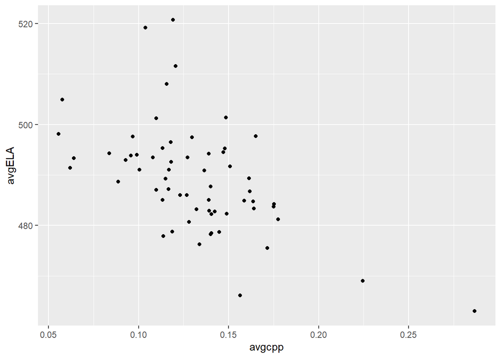

```r
ggplot(merged_school_acs, aes(x = avgcpp, y = avgELA)) + geom_point()
```

```r
cor(merged_school_acs$avgcpp, merged_school_acs$avgELA)
```

```
## [1] -0.5541346
```

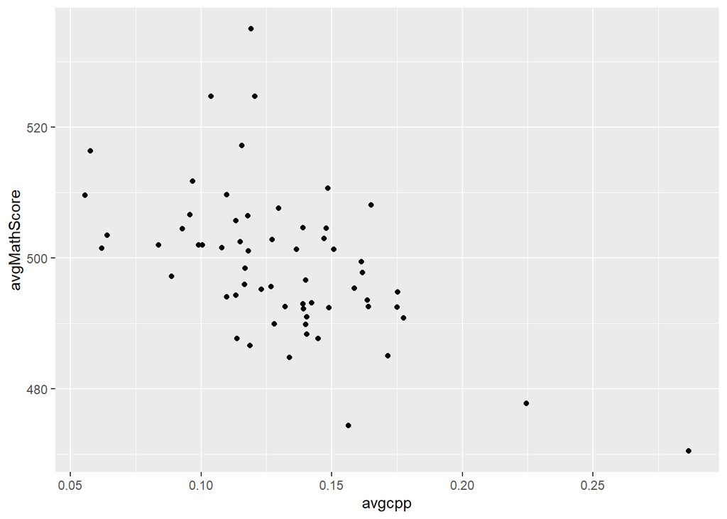

```r
ggplot(merged_school_acs, aes(x = avgcpp, y = avgMathScore)) + geom_point()
```

```r
cor(merged_school_acs$avgcpp, merged_school_acs$avgMathScore)
```

```
## [1] -0.5556442
```

As expected, There is a negative relationship between poverty and test performance. The higher the poverty, the lower the test performance.

Has this relationship changed over time?

```r
#Create a merged dataset that includes year info
merge_withyear <- left_join(schools, acs, by = c("year", "county_name"))
```

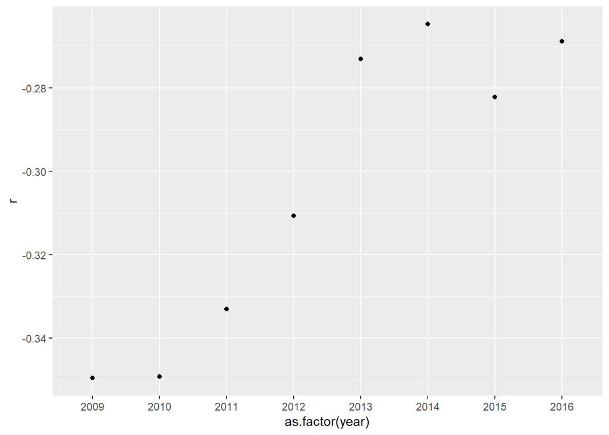

```r
correlate <- merge_withyear %>%
  drop_na() %>%
  group_by(year) %>%
  summarize(r = cor(county_per_poverty, mean_math_score)) %>%
  ggplot(aes(as.factor(year), r)) + geom_point()

correlate
```

This inverse relationship is generally becoming less strong as time passes. This is good news!

```r
lm <- lm(mean_math_score~county_per_poverty, data = merge_withyear)
summary(lm)
```

```
##
## Call:
## lm(formula = mean_math_score ~ county_per_poverty, data = merge_withyear)
##
## Residuals:
##     Min      1Q  Median      3Q     Max
## -301.02 -190.22  -83.16  185.98  279.57
##
## Coefficients:
##                    Estimate Std. Error t value Pr(>|t|)
## (Intercept)         551.397      2.874  191.82   <2e-16 ***
## county_per_poverty -398.337     18.043  -22.08   <2e-16 ***
## ---
## Signif. codes:  0 '***' 0.001 '**' 0.01 '*' 0.05 '.' 0.1 ' ' 1
##
## Residual standard error: 190.2 on 26791 degrees of freedom
##   (8870 observations deleted due to missingness)
## Multiple R-squared:  0.01787,    Adjusted R-squared:  0.01783
## F-statistic: 487.4 on 1 and 26791 DF,  p-value: < 2.2e-16
```

```r
lm1 <- lm(mean_math_score ~ county_per_poverty + per_free_lunch + county_per_poverty:per_free_lunch, data = merge_withyear)
summary(lm1)
```

```
##
## Call:
## lm(formula = mean_math_score ~ county_per_poverty + per_free_lunch +
##     county_per_poverty:per_free_lunch, data = merge_withyear)
##
## Residuals:
##     Min      1Q  Median      3Q     Max
## -306.20 -186.42  -95.42  188.90  283.65
##
## Coefficients:
##                                   Estimate Std. Error t value Pr(>|t|)
## (Intercept)                        596.505      5.355 111.395   <2e-16 ***
## county_per_poverty                -589.525     45.111 -13.068   <2e-16 ***
## per_free_lunch                    -144.708     10.143 -14.267   <2e-16 ***
## county_per_poverty:per_free_lunch  622.220     65.678   9.474   <2e-16 ***
## ---
## Signif. codes:  0 '***' 0.001 '**' 0.01 '*' 0.05 '.' 0.1 ' ' 1
##
## Residual standard error: 189.3 on 26786 degrees of freedom
##   (8873 observations deleted due to missingness)
## Multiple R-squared:  0.02658,    Adjusted R-squared:  0.02647
## F-statistic: 243.8 on 3 and 26786 DF,  p-value: < 2.2e-16
```

```r
lm2 <- lm(mean_math_score ~ county_per_poverty + per_reduced_lunch + county_per_poverty:per_reduced_lunch, data = merge_withyear)
summary(lm2)
```

```
##
## Call:
## lm(formula = mean_math_score ~ county_per_poverty + per_reduced_lunch +
##     county_per_poverty:per_reduced_lunch, data = merge_withyear)
##
## Residuals:
##     Min      1Q  Median      3Q     Max
## -823.97 -183.27  -68.08  181.07  313.83
##
## Coefficients:
##                                      Estimate Std. Error t value Pr(>|t|)
## (Intercept)                           513.955      4.544 113.115  < 2e-16
## county_per_poverty                   -486.186     28.250 -17.210  < 2e-16
## per_reduced_lunch                     485.622     61.557   7.889 3.16e-15
## county_per_poverty:per_reduced_lunch 1627.993    395.975   4.111 3.95e-05
##
## (Intercept)                          ***
## county_per_poverty                   ***
## per_reduced_lunch                    ***
## county_per_poverty:per_reduced_lunch ***
## ---
## Signif. codes:  0 '***' 0.001 '**' 0.01 '*' 0.05 '.' 0.1 ' ' 1
##
## Residual standard error: 186.8 on 26786 degrees of freedom
##   (8873 observations deleted due to missingness)
## Multiple R-squared:  0.05198,    Adjusted R-squared:  0.05187
## F-statistic: 489.5 on 3 and 26786 DF,  p-value: < 2.2e-16
```

Yes, this relationship between poverty and test performance is moderated by access to free/reduced price lunch.